# Homework 4

Magdalena Bogdańska

Linear and mixed models with examples for biological and medical data

## Task

Load the dataset.

Plot graphical summaries for the dataset (show either distribution of spine’s length in each group or mean+/-sd).

Perform one-way ANOVA and post-hoc tests. Are there differences among different post hoc tests? Compare different approaches and discuss results.

Choose suitable contrasts and test them. Prepare graphical summaries and discuss results.

Create a knitr report that summarises the story/relation for spine’s length and groups of mice.

## Data

```r
load("17df9d1fc4f43962a91b9ab14b7b8e6f.rda")
head(spines)
```

```
##   Group ID   length
## 1  TG +  1 2.118701
## 2  TG +  2 2.481908
## 3  TG +  3 2.055486
## 4  TG +  4 1.748784
## 5  TG +  5 2.283120
## 6  TG +  6 2.022596
```

```r
attach(spines)
unique(Group)
```

```
## [1] TG + TG - WT + WT -
## Levels: TG + TG - WT + WT -
```

## Descriptive statistics and graphical summary

```r
by(length,Group,summary)
```

```
## Group: TG +
##    Min. 1st Qu.  Median    Mean 3rd Qu.    Max.
##   1.677   2.016   2.166   2.230   2.419   3.232
## --------------------------------------------------------
## Group: TG -
##    Min. 1st Qu.  Median    Mean 3rd Qu.    Max.
##   1.740   1.868   1.947   2.014   2.126   2.645
## --------------------------------------------------------
## Group: WT +
##    Min. 1st Qu.  Median    Mean 3rd Qu.    Max.
##   1.565   1.779   1.846   1.904   2.076   2.262
## --------------------------------------------------------
## Group: WT -
##    Min. 1st Qu.  Median    Mean 3rd Qu.    Max.
##   1.720   1.868   1.967   1.970   2.065   2.365
```

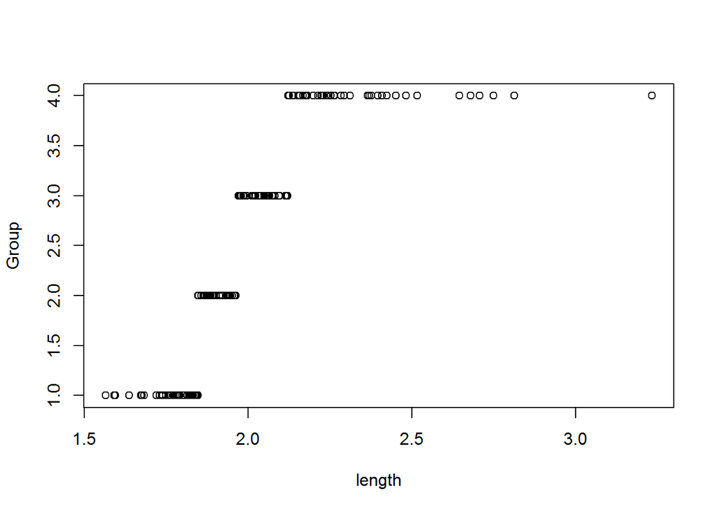

```r
qqplot(length,Group)
```

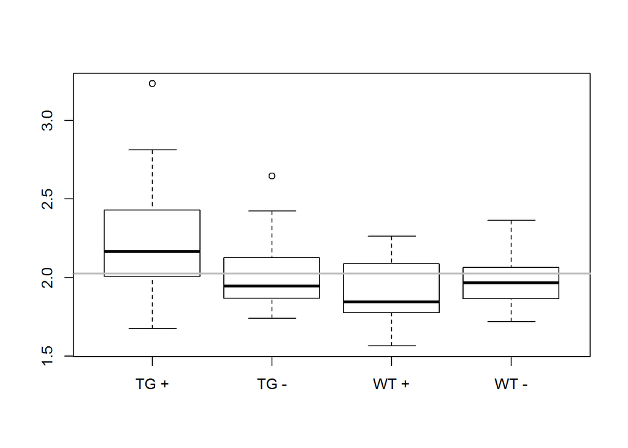

```r
boxplot(length~Group)
abline(h=mean(length), col='grey', lwd=2)
```

## One-way ANOVA

```r
anova(lm(length~Group))
```

```
## Analysis of Variance Table
##
## Response: length
##            Df Sum Sq Mean Sq F value    Pr(>F)
## Group       3 2.4069 0.80230  15.415 7.097e-09 ***
## Residuals 163 8.4836 0.05205
## ---
## Signif. codes:  0 '***' 0.001 '**' 0.01 '*' 0.05 '.' 0.1 ' ' 1
```

Results of one-way ANOVA suggest that differences between means in groups of mice are significant statistically.

## Post-hoc tests

One can observe that number of elements in each group is different, thus we should not use neither Tukey nor HSD test, however I will do it only for comparison.

```r
sum(spines$Group=="TG +")
```

```
## [1] 40
```

```r
sum(spines$Group=="TG -")
```

```
## [1] 41
```

```r
sum(spines$Group=="TG -")
```

```
## [1] 41
```

```r
sum(spines$Group=="WT -")
```

```
## [1] 46
```

```r
model.anova<-aov(length~Group)
TukeyHSD(model.anova)
```

```
##   Tukey multiple comparisons of means
##     95% family-wise confidence level
##
## Fit: aov(formula = length ~ Group)
##
## $Group
##                  diff         lwr         upr     p adj
## TG --TG + -0.21559730 -0.34720322 -0.08399137 0.0002067
## WT +-TG + -0.32585864 -0.45827446 -0.19344283 0.0000000
## WT --TG + -0.25977801 -0.38780312 -0.13175290 0.0000026
## WT +-TG - -0.11026135 -0.24186727  0.02134457 0.1346639
## WT --TG - -0.04418072 -0.17136798  0.08300655 0.8039503
## WT --WT +  0.06608063 -0.06194448  0.19410574 0.5390200
```

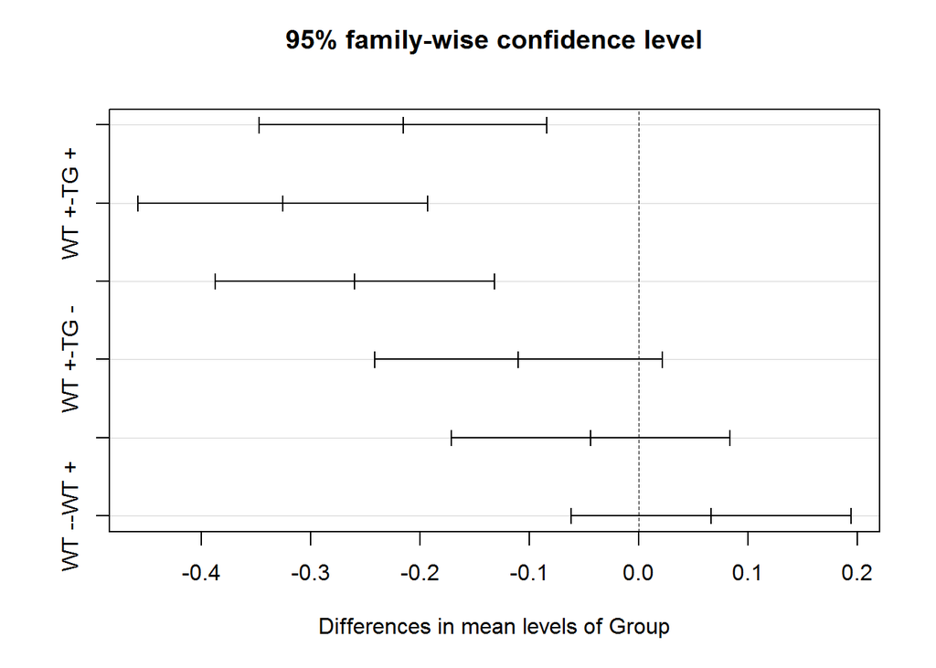

```r
plot(TukeyHSD(model.anova))
```

I have plotted differences in means between pairs of groups with confidence intervals. If confidence interval for difference between two means doesn’t contain 0, then those means are different (with significance level 0.05). In this case group TG+ is different from all other groups.

```r
library(agricolae)
HSD.test(model.anova,"Group", console = TRUE)
```

```
##
## Study: model.anova ~ "Group"
##
## HSD Test for length
##
## Mean Square Error:  0.05204635
##
## Group,  means
##
##        length       std  r      Min      Max
## TG - 2.014115 0.2031950 41 1.739734 2.645106
## TG + 2.229712 0.3387973 40 1.676874 3.232469
## WT - 1.969934 0.1339296 46 1.720331 2.364816
## WT + 1.903854 0.1992482 40 1.565252 2.261947
##
## alpha: 0.05 ; Df Error: 163
## Critical Value of Studentized Range: 3.670918
##
## Harmonic Mean of Cell Sizes  41.61059
## Honestly Significant Difference: 0.1298279
##
## Means with the same letter are not significantly different.
##
## Groups, Treatments and means
## a     TG +    2.23
## b     TG -    2.014
## b     WT -    1.97
## b     WT +    1.904
```

```r
SNK.test(model.anova, "Group", console = TRUE)
```

```
##
## Study: model.anova ~ "Group"
##
## Student Newman Keuls Test
## for length
##
## Mean Square Error:  0.05204635
##
## Group,  means
##
##        length       std  r      Min      Max
## TG - 2.014115 0.2031950 41 1.739734 2.645106
## TG + 2.229712 0.3387973 40 1.676874 3.232469
## WT - 1.969934 0.1339296 46 1.720331 2.364816
## WT + 1.903854 0.1992482 40 1.565252 2.261947
##
## alpha: 0.05 ; Df Error: 163
##
## Critical Range
##          2          3          4
## 0.09876265 0.11830364 0.12982786
##
## Harmonic Mean of Cell Sizes  41.61059
##
## Different value for each comparison
## Means with the same letter are not significantly different.
##
## Groups, Treatments and means
## a     TG +    2.23
## b     TG -    2.014
## b     WT -    1.97
## b     WT +    1.904
```

In LSD and Scheffe test there is no assumption of equal sizes of groups.

```r
LSD.test(model.anova, "Group", p.adj="bonferroni", console = TRUE)
```

```
##
## Study: model.anova ~ "Group"
##
## LSD t Test for length
## P value adjustment method: bonferroni
##
## Mean Square Error:  0.05204635
##
## Group,  means and individual ( 95 %) CI
##
##        length       std  r      LCL      UCL      Min      Max
## TG - 2.014115 0.2031950 41 1.943761 2.084469 1.739734 2.645106
## TG + 2.229712 0.3387973 40 2.158485 2.300940 1.676874 3.232469
## WT - 1.969934 0.1339296 46 1.903514 2.036355 1.720331 2.364816
## WT + 1.903854 0.1992482 40 1.832626 1.975082 1.565252 2.261947
##
## alpha: 0.05 ; Df Error: 163
## Critical Value of t: 2.67084
##
## Minimum difference changes for each comparison
##
## Means with the same letter are not significantly different.
##
## Groups, Treatments and means
## a     TG +    2.23
## b     TG -    2.014
## b     WT -    1.97
## b     WT +    1.904
```

```r
scheffe.test(model.anova, "Group", console = TRUE)
```

```
##
## Study: model.anova ~ "Group"
##
## Scheffe Test for length
##
## Mean Square Error  : 0.05204635
##
## Group,  means
##
##        length       std  r      Min      Max
## TG - 2.014115 0.2031950 41 1.739734 2.645106
## TG + 2.229712 0.3387973 40 1.676874 3.232469
## WT - 1.969934 0.1339296 46 1.720331 2.364816
## WT + 1.903854 0.1992482 40 1.565252 2.261947
##
## alpha: 0.05 ; Df Error: 163
## Critical Value of F: 2.660061
##
## Harmonic Mean of Cell Sizes  41.61059
## Minimum Significant Difference: 0.141291
##
## Means with the same letter are not significantly different.
##
## Groups, Treatments and means
## a     TG +    2.23
## b     TG -    2.014
## b     WT -    1.97
## b     WT +    1.904
```

Result of all test is then the following: group “TG +”" is different from other groups. Groups “TG -”, “WT -”" and “WT +” are not significantly different.

## Contrasts

```r
(k<-length(levels(Group)))
```

```
## [1] 4
```

```r
t(contr.treatment(k))
```

```
##   1 2 3 4
## 2 0 1 0 0
## 3 0 0 1 0
## 4 0 0 0 1
```

Successive differences contrasts:

```r
library("MASS")
t(contr.sdif(k))
```

```
##         1     2     3    4
## 2-1 -0.75  0.25  0.25 0.25
## 3-2 -0.50 -0.50  0.50 0.50
## 4-3 -0.25 -0.25 -0.25 0.75
```

Helment contrasts:

```r
t(contr.helmert(k))
```

```
##       1  2  3 4
## [1,] -1  1  0 0
## [2,] -1 -1  2 0
## [3,] -1 -1 -1 3
```

Result of regression with default contrasts:

```r
summary(lm(length~Group))
```

```
##
## Call:
## lm(formula = length ~ Group)
##
## Residuals:
##     Min      1Q  Median      3Q     Max
## -0.5528 -0.1356 -0.0547  0.1328  1.0028
##
## Coefficients:
##             Estimate Std. Error t value Pr(>|t|)
## (Intercept)  2.22971    0.03607  61.814  < 2e-16 ***
## GroupTG -   -0.21560    0.05070  -4.252 3.55e-05 ***
## GroupWT +   -0.32586    0.05101  -6.388 1.69e-09 ***
## GroupWT -   -0.25978    0.04932  -5.267 4.33e-07 ***
## ---
## Signif. codes:  0 '***' 0.001 '**' 0.01 '*' 0.05 '.' 0.1 ' ' 1
##
## Residual standard error: 0.2281 on 163 degrees of freedom
## Multiple R-squared:  0.221,  Adjusted R-squared:  0.2067
## F-statistic: 15.42 on 3 and 163 DF,  p-value: 7.097e-09
```

Result of regression using successive differences contrasts:

```r
summary(lm(length~Group, contrasts=list(Group=t(contr.sdif(k+1)))))
```

```
##
## Call:
## lm(formula = length ~ Group, contrasts = list(Group = t(contr.sdif(k +
##     1))))
##
## Residuals:
##     Min      1Q  Median      3Q     Max
## -0.5528 -0.1356 -0.0547  0.1328  1.0028
##
## Coefficients: (2 not defined because of singularities)
##             Estimate Std. Error t value Pr(>|t|)
## (Intercept)  2.03602    0.07633  26.672  < 2e-16 ***
## Group1      -0.12762    0.12919  -0.988 0.324685
## Group2       0.28168    0.07073   3.982 0.000103 ***
## Group3       0.17634    0.08721   2.022 0.044807 *
## Group4            NA         NA      NA       NA
## Group5            NA         NA      NA       NA
## ---
## Signif. codes:  0 '***' 0.001 '**' 0.01 '*' 0.05 '.' 0.1 ' ' 1
##
## Residual standard error: 0.2281 on 163 degrees of freedom
## Multiple R-squared:  0.221,  Adjusted R-squared:  0.2067
## F-statistic: 15.42 on 3 and 163 DF,  p-value: 7.097e-09
```

In order to have qualitative ordered variable, I use function ordered.

```r
summary(lm(length~ordered(Group)))
```

```
##
## Call:
## lm(formula = length ~ ordered(Group))
##
## Residuals:
##     Min      1Q  Median      3Q     Max
## -0.5528 -0.1356 -0.0547  0.1328  1.0028
##
## Coefficients:
##                  Estimate Std. Error t value Pr(>|t|)
## (Intercept)       2.02940    0.01768 114.764  < 2e-16 ***
## ordered(Group).L -0.19892    0.03497  -5.688 5.83e-08 ***
## ordered(Group).Q  0.14084    0.03537   3.982 0.000103 ***
## ordered(Group).C  0.01588    0.03575   0.444 0.657583
## ---
## Signif. codes:  0 '***' 0.001 '**' 0.01 '*' 0.05 '.' 0.1 ' ' 1
##
## Residual standard error: 0.2281 on 163 degrees of freedom
## Multiple R-squared:  0.221,  Adjusted R-squared:  0.2067
## F-statistic: 15.42 on 3 and 163 DF,  p-value: 7.097e-09
```

Both linear and quadratic contrast is statistically significant, showing possible linear or quadratic relation between group and length of spine.

One can also compare all contrasts in the following way:

```r
contrs <- apropos("contr\\.")
coeffs <- sapply(contrs, function(i) lm(length~Group,contrasts=list(Group=get(i)))$coefficients)
t(coeffs)
```

```
##                 (Intercept)     Group1      Group2      Group3
## contr.helmert      2.029404 -0.1077986 -0.07268667 -0.01982317
## contr.poly         2.029404 -0.1989196  0.14083896  0.01587743
## contr.SAS          1.969934  0.2597780  0.04418072 -0.06608063
## contr.sdif         2.029404 -0.2155973 -0.11026135  0.06608063
## contr.sum          2.029404  0.2003085 -0.01528881 -0.12555016
## contr.treatment    2.229712 -0.2155973 -0.32585864 -0.25977801
```